# DAR F23 Project Status Notebook Template

Hockey Analytics

Caleb Smith

2023-10-16

## Weekly Work Summary

**NOTE:** Follow an outline format; use bullets to express individual points.

- RCS ID: **Always** include this!

smithc22

- Project Name: **Always** include this!

Hockey Analytics

- Summary of work since last week
  - Describe the important aspects of what you worked on and accomplished

  *Re-ran clustering analysis with the new features* Attempted to handle angle better and analysed the results of doing so
- NEW: Summary of github issues added and worked
  - Issues that you’ve submitted
  - Issues that you’ve self-assigned and addressed

  *N/A
- Summary of github commits
  - include branch name(s) dar-smithc22
  - include browsable links to all external files on github
  - Include links to shared Shiny apps
- List of presentations, papers, or other outputs
  - Include browsable links

  https://docs.google.com/presentation/d/1tc2zpWd-nTNv9Cp7yucLfOVzOJNdGTWe10eFp3ulN0U/edit#slide=id.g28b7e1d64e4_1_3

  https://docs.google.com/presentation/d/1tc2zpWd-nTNv9Cp7yucLfOVzOJNdGTWe10eFp3ulN0U/edit#slide=id.g28b7e1d64e4_1_3
- List of references (if necessary)
- Indicate any use of group shared code base
- Indicate which parts of your described work were done by you or as part of joint efforts

  As far as I remember all work here is my own
- **Required:** Provide illustrating figures and/or tables

## Personal Contribution

- Clearly defined, unique contribution(s) done by you: code, ideas, writing…
- Include github issues you’ve addressed

  The code here is the main contribution I’ve made over the past few weeks

## Analysis: Question 1: Are there failure types we haven’t identified yet?

### Question being asked

*Provide in natural language a statement of what question you’re trying to answer*

Are there more modes of failures that I missed in the last analysis?

### Data Preparation

*Provide in natural language a description of the data you are using for this analysis* I’m using the older data frame here without more detail on defenders, since it wasn’t created yet at the time of this analysis

*Include a step-by-step description of how you prepare your data for analysis*

1. Drop the goals column, as we are trying to classify types of shots in a manner that would let us predict the outcome.
2. One hot encode
3. Scale the data for even treatment of features
4. Pull the goals out, since we are focusing on modes of failures. Doing this after scaling makes assigning goals to clusters after the fact easier, and since there are so few goals it doesn’t mess with the scaling that much

*If you’re re-using dataframes prepared in another section, simply re-state what data you’re using*

```r
# Include all data processing code (if necessary), clearly commented
#This is taken from my previous notebook
shots <- readRDS("shots_stats_goal.df.Rds")#Need to make sure this is grabb
insertCol <- function(data,loc,col){
  newData <- cbind(data[,1:loc],col)
  newData <- cbind(newData,data[,(loc+1):ncol(data)])
  return(newData)
}
library(data.table)
library(mltools)
library(dplyr)
```

```r
library(plotly)
library(umap)
library(ggplot2)
library(scatterplot3d)
library(rgl)
library(car)
library(grid)
library(gridExtra)
library(kableExtra)
library(heatmaply)
library(gplots)
library(tibble)
shotsNum <- shots
goals <- shots[shots$outcomes.goal == 1,]
#One-hot encoding and making sure goals are dropped
shotsNum$goalieScreened = as.factor(shotsNum$goalieScreened)
shotsNum$oppDefenders = as.factor(shotsNum$oppDefenders)
shotsNum$sameDefenders = as.factor(shotsNum$sameDefenders)
shotsNum <- shotsNum[,1:11]
shotsNum <- one_hot(dt = as.data.table(shotsNum))
labels <- ifelse(shots$outcomes.goal == 1, TRUE, FALSE)#creating labels to use for graph coloring
shotsNum <- scale(shotsNum)
#Doing something similar to the goals to allow me to figure out which cluster they're in
goalsScaledCol <- goals
#goalsScaled$goalieScreened = as.factor(goalsScaled$goalieScreened)
#goalsScaled$oppDefenders = as.factor(goalsScaled$oppDefenders)
#goalsScaled$sameDefenders = as.factor(goalsScaled$sameDefenders)
#goalsScaled <- goalsScaled[,1:11]
#goalsScaled <- one_hot(dt = as.data.table(goalsScaled)) #Need to add 0 vector of opp_defender4, same defenders 1 and 2
#goalsScaled <- as.tibble(goalsScaled)
#goalsScaled %>% add_column(sameDefenders_1 = numeric(9),.after = "sameDefenders_0")
#this is garbage, I'm just going to write an insert function
#goalsScaledCol <- insertCol(goalsScaled,8,numeric(9))
#goalsScaledCol <- insertCol(goalsScaledCol,9,numeric(9))
#goalsScaledCol <- insertCol(goalsScaledCol,13,numeric(9))
#Turns out I don't need to insert those columns. Oh well, now i have it for later

#Getting right format attempt 2
goalsScaledCol <- apply(goals,2,as.numeric)
#goalScreened <- ifelse(goals$goalieScreened,2,1) #time to make another transform function

#goalsScaled <- scale(goalsScaledCol, attr(temp, "scaled:center"), attr(temp, "scaled:scale"))

#This is needed for finding some of the medians
shots2 <- shots
shots2[,10] <- as.numeric(shots$goalieScreened)
shots2[,12] <- as.numeric(shots$outcomes.goal)
fails <- as.data.frame(shotsNum) %>% filter(shots$outcomes.goal == 0)
shots2NoGoals <- shots2 %>% filter(shots2$outcomes.goal == 1)
temp <- scale(apply(shots2NoGoals,2,as.numeric))
goalsScaled <- scale(goalsScaledCol, attr(temp, "scaled:center"), attr(temp, "scaled:scale"))
#Seed setting - UMAP still acts wonky regardless of this, so I'll be reading it in from RDS files for consistency
custom.config <- umap.defaults
custom.config$random_state <- 2392023
set.seed(100)

select <- dplyr::select

#General Functions


assignCluster <- function(centers,data){
  distVec <- numeric(nrow(centers))
  for(i in 1:(nrow(centers))){
    distVec[i] <- dist(rbind(data,centers[i,2:(ncol(centers))]))
  }
  return(which.min(distVec))
}

plotAll <- function(data,toFile = FALSE,fileName = "graph.pdf"){
  plotsList <- list()
  for(i in 1:(ncol(data)-1) ){
    p <- NULL
    axis <- colnames(data)
    axises <- axis[i]
    if(i >= 8){#Hard coded to do barplots on the categorical variables. Will change this later to check the class of the column if needed
      p <-  ggplot(data = data,aes_string(x = axises,fill = "cluster"))+
  geom_bar()
    }else{
  p <-  ggplot(data = data,aes_string(x = axises,color = "cluster"))+
  geom_density()
    }
  plotsList[[i]] <- p
  }
  if(toFile){
  pdf(fileName, width = 8, height = 12)
  do.call("grid.arrange", c(plotsList, ncol = 3))
  dev.off()
  }else{
    do.call("grid.arrange", c(plotsList, ncol = 3))
  }
}
#Not coloring by cluster
plotAllNoCluster <- function(data,toFile = FALSE,fileName = "graph.pdf"){
  plotsList <- list()
  for(i in 1:(ncol(data)-1) ){
    p <- NULL
    axis <- colnames(data)
    axises <- axis[i]
    if(i >= 8){#Hard coded to do barplots on the categorical variables. Will change this later to check the class of the column if needed
      p <-  ggplot(data = data,aes_string(x = axises))+
  geom_bar()
    }else{
  p <-  ggplot(data = data,aes_string(x = axises))+
  geom_density()
    }
  plotsList[[i]] <- p
  }
  if(toFile){
  pdf(fileName, width = 8, height = 12)
  do.call("grid.arrange", c(plotsList, ncol = 3))
  dev.off()
  }else{
    do.call("grid.arrange", c(plotsList, ncol = 3))
  }
}

#Generates a plot to use the elbow test for K-means. I stole this from IDM
wssplot <- function(data, nc=15, seed=100){
  wss <- data.frame(cluster=1:nc, quality=c(0))
  for (i in 1:nc){
    set.seed(seed)
    wss[i,2] <- kmeans(data, centers=i)$tot.withinss}
  ggplot(data=wss,aes(x=cluster,y=quality)) +
    geom_line() +
    ggtitle("Quality of k-means by Cluster")
}
#Displays medians of the data for each cluster passed
displayMeds <- function(data, clusters,nClust){
  temp <- data %>% filter(clusters == 1)
  results <- apply(temp,2,median)
  for(i in 2:nClust){
    temp <- data %>% filter(clusters == i)
    results <- rbind.data.frame(results,apply(temp,2,median))
  }
  return(results)
}
```

### Analysis: Methods and results

*Describe in natural language a statement of the analysis you’re trying to do*

I’m trying to see if I can use UMAP and K-means to go from three clusters to five, as was suggested at a meeting. All scatterplots will be of UMAP projections. To assess clusters, I will first form and graph a UMAP projection. Then, combined with the elbow test, I will assess and plot the clusters to determine the proper number. To analyse my clusters after creation, I will create a heat map and possibly a summary table. I will name the clusters to keep the differences between them easy to remember.

*Provide clearly commented analysis code; include code for tables and figures!*

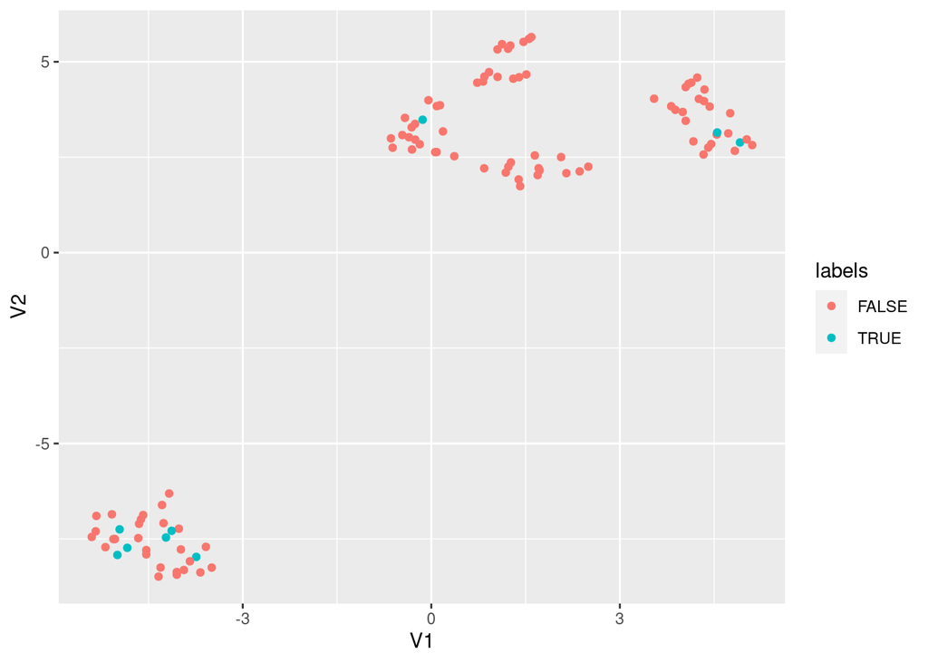

```r
# Include all analysis code, clearly commented
# If not possible, screen shots are acceptable.
# If your contributions included things that are not done in an R-notebook,
#   (e.g. researching, writing, and coding in Python), you still need to do
#   this status notebook in R.  Describe what you did here and put any products
#   that you created in github. If you are writing online documents (e.g. overleaf
#   or google docs), you can include links to the documents in this notebook
#   instead of actual text.

#All shots were under 300 distance
#plotAllNoCluster(goals,TRUE,"Goals_Only.pdf")
#Don't worry about this, not important

#Trying to do 5 clusters instead of 3 on the UMAP
umapNoDistance <- readRDS("UMAP_Distance_Dropped")

ggplot()+
 geom_point(data = as.data.frame(umapNoDistance$layout),aes(x = V1,y = V2,color = labels))
```

The goal is to see if I can break this up into more than the three obvious clusters, since it looks like the ‘V’ formation could potentially be split

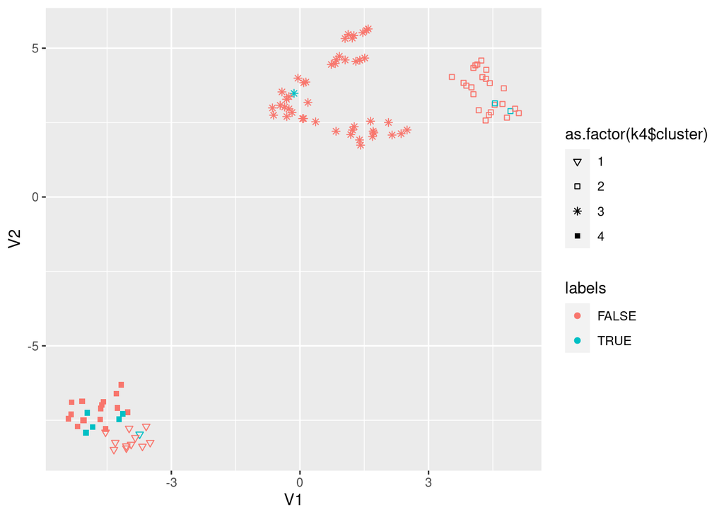

```r
k4 <- kmeans(umapNoDistance$layout,4)

ggplot()+
  geom_point(data = as.data.frame(umapNoDistance$layout),aes(x = V1,y = V2,color = labels,shape = as.factor(k4$cluster))) +
  scale_shape_manual(values = c(25,22,8,15))
```

Unfortunately, K-means ends up just splitting the goals corner up in a way that doesn’t really make sense. I’ll try it on the umap I made of the fails and see if I can put that into more clusters

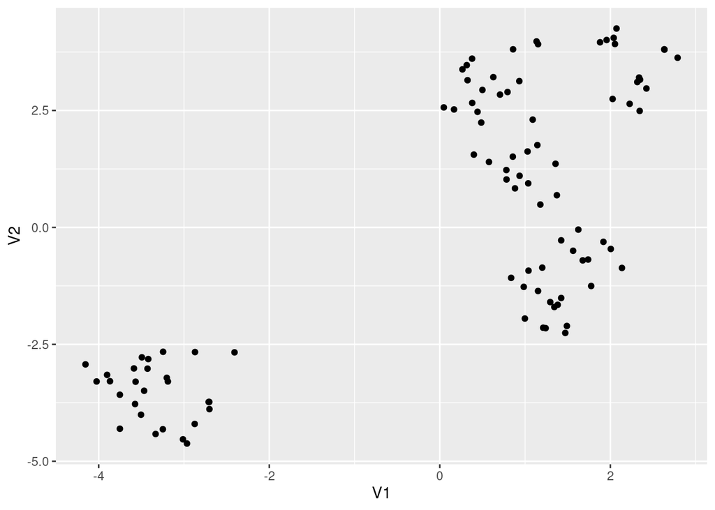

```r
#Doesn't seem to want to work. I'll try the one I ran on the fails instead
umapFails <- umap(fails,n_components = 2, config = custom.config)
ggplot()+
 geom_point(data = as.data.frame(umapFails$layout),aes(x = V1,y = V2))
```

This is fairly similar to the previous projection, with three main clusters and one of the clusters that could be divided into 3.

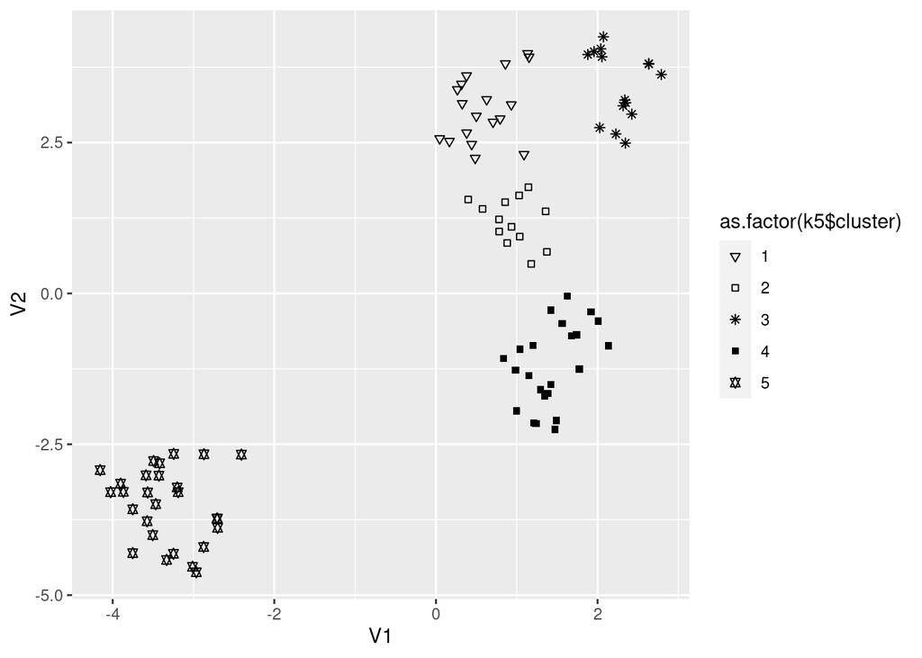

```r
k5 <- kmeans(umapFails$layout,5)
#This looks pretty
ggplot()+
  geom_point(data = as.data.frame(umapFails$layout),aes(x = V1,y = V2,shape = as.factor(k5$cluster))) +
  scale_shape_manual(values = c(25,22,8,15,11))
```

Fortunately, K-means is able to break up the clusters into nice breaks here, which is exactly what I was hoping for.

```r
#Analyzing this
ggData <- cbind.data.frame(shots2NoGoals,k5$cluster)
ggData[,13] <- as.factor(k5$cluster)
colnames(ggData) <- append(colnames(shots2),"cluster")

plotAll(ggData,TRUE,"NoGoalGraphs.pdf")
```

```r
#Heatmap as well since 5 clusters on density graphs starts looking disgusting
#Data preperation
shotsNumRegular <- as.data.frame(scale(apply(shots2NoGoals,2,as.numeric)))[,1:11]
preimageCenters <- shotsNumRegular%>% group_by(as.factor(k5$cluster) ) %>% summarise_all(.funs =  mean)
  #apply(fails,2,median) #do this for each factor
heatData <- as.matrix(preimageCenters[,2:11])

goalClust <- numeric(5)
for(i in 1:(nrow(goalsScaledCol))){
  goalClust[assignCluster(preimageCenters,goalsScaled[i,])] <- goalClust[assignCluster(preimageCenters,goalsScaled[i,])] + 1 #<- assignCluster(preimageCenters,goalsScaled[i,])
}
goalClust#Almost all 5, a 4 and a 1 in there
```

```
## [1] 1 0 0 1 7
```

```r
clusterPercents <- goalClust/k5$size
clusterPercents
```

```
## [1] 0.05555556 0.00000000 0.00000000 0.04347826 0.25925926
```

The majority of the goals were in cluster 5, with 1 in 4 and 1 in 1. This will be kept in mind in the analysis at the end of the question. The heatmap below is of the cluster centers, and will be used along with the summary table (which includes the means of each feature for each cluster) to name the clusters

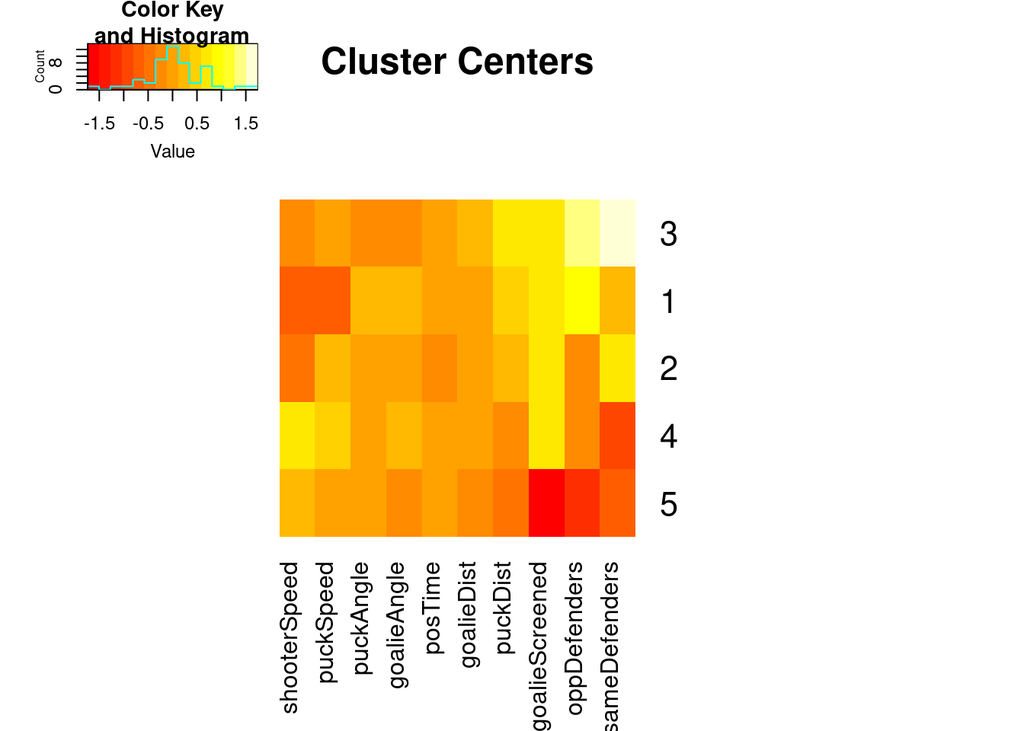

```r
#goalsScaled
#preimageCenters

heatmap.2(heatData,
          main = "Cluster Centers",
          scale = "none",
          trace = "none",
          dendrogram = "none",
          Colv = TRUE,
          Rowv = TRUE,
          margins = c(8,16))
```

```r
#finding which cluster the goals are in
#goalProj <- predict(umapFails,goals)
#Let's make a summary table as well
summaryTable <- shots2NoGoals %>% group_by(as.factor(k5$cluster)) %>% summarise_all(.funs = mean)
kbl(summaryTable[,1:8],booktabs = T) %>% kable_styling(latex_options = c("striped","scaled_down"),full_width = F,position = "left")
```

| as.factor(k5$cluster) | puckDist | puckAngle | puckSpeed | shooterSpeed | goalieDist | goalieAngle | posTime |
| --- | --- | --- | --- | --- | --- | --- | --- |
| 1 | 497.5395 | 95.76245 | 31.33067 | 11.28901 | 73.55111 | 88.37170 | 32.94444 |
| 2 | 479.7380 | 83.37737 | 44.56910 | 11.62327 | 68.04036 | 77.84730 | 24.84615 |
| 3 | 529.8660 | 74.37155 | 41.96123 | 13.57873 | 79.63267 | 65.44688 | 32.93333 |
| 4 | 389.3093 | 82.23158 | 47.74488 | 20.97168 | 73.41236 | 82.64432 | 33.91304 |
| 5 | 330.4890 | 84.04700 | 41.36843 | 18.13588 | 62.18259 | 68.31499 | 30.40741 |

```r
kbl(summaryTable[,9:ncol(summaryTable)],booktabs = T) %>% kable_styling(latex_options = c("striped","scaled_down"),full_width = F,position = "left")
```

| sameDefenders | oppDefenders | goalieScreened | rightHanded | outcomes.goal |
| --- | --- | --- | --- | --- |
| 0.7222222 | 2.888889 | 2 | 0.6111111 | 1 |
| 1.0000000 | 2.000000 | 2 | 0.6923077 | 1 |
| 1.8000000 | 3.266667 | 2 | 0.2000000 | 1 |
| 0.0000000 | 2.000000 | 2 | 0.5652174 | 1 |
| 0.0740741 | 1.111111 | 1 | 0.3703704 | 1 |

### Discussion of results

*Provide in natural language a clear discussion of your observations.*

Cluster 3 ‘Lousy shot, left side’: Full house, lots of players on both teams, pretty far from the goal. The hail mary one from the three cluster group. The angle difference between puck and goalie seems solid

Cluster 4 ‘Goalie Save’: Looks like it has a good chance, close to the goal and very fast. Appears to have less team assistance than 5, with more opposing team members. Also has a much more centered goalie angle, cluster 5 is biased left of the goalie!

## Analysis: Question 2 : Can we make these clusters more descriptive by adding more features?

### Question being asked

*Provide in natural language a statement of what question you’re trying to answer*

As you probably noticed, the cluster names are rather vague in the previous analysis. However, thanks to some work from Amy and Dr. Morgan, we are able to get more data about the defenders on the ice, and what caused the shot to miss. I’m seeing how releveant this is to modes of failure.

### Data Preparation

*Provide in natural language a description of the data you are using for this analysis*

I’m using all the shots from our newest RDS

*Include a step-by-step description of how you prepare your data for analysis*

1. Drop the goals column, as we are trying to classify types of shots in a manner that would let us predict the outcome.
2. One hot encode
3. Scale the data for even treatment of features

*If you’re re-using dataframes prepared in another section, simply re-state what data you’re using*

Reading in our new data frame and running the same preparation it was given in question 1, and also making the differential between the puck and goalie a factor. After a discussion with Dr. Morgan on the WebEx, I dropped closestDef as irrelevant.

```r
# Include all data processing code (if necessary), clearly commented
#screw it im gonna see if i can get a decent umap with the goals to determine their cluster
new_df <- readRDS("shots_stats_goal.df.newest.Rds")
shotsNew <- new_df[,!names(new_df) %in% c("closestDef","outcomes","shotOutcome")]
shotsNew$angleDiff <- abs(new_df$goalieAngle - new_df$puckAngle)
shotsNumNew <- shotsNew
sumTab <- shotsNew
#Now rerunning all the scaling to make it work
#shotsNew$goalieScreened = as.factor(shotsNew$goalieScreened)
shotsNew$NumOffense = as.factor(shotsNew$NumOffense)
shotsNew$NumDefense = as.factor(shotsNew$NumDefense)
#shotsNew$rightHanded = as.factor(shotsNew$rightHanded)
shotsQ3 <- shotsNew
shotsNew <- one_hot(dt = as.data.table(shotsNew))
shotsNew <- scale(shotsNew)

custom.config2 <- umap.defaults
custom.config2$random_state <- 10112023
```

### Analysis: Methods and Results

*Describe in natural language a statement of the analysis you’re trying to do*

Rerunning analysis I did for question 1 with the new data frame

*Provide clearly commented analysis code; include code for tables and figures!*

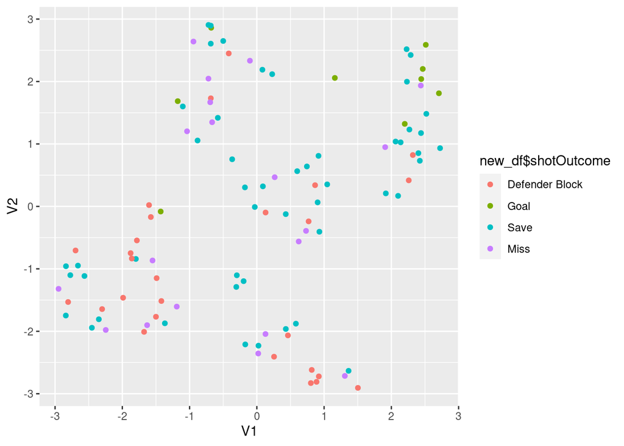

```r
# Include all analysis code, clearly commented
# If not possible, screen shots are acceptable.
# If your contributions included things that are not done in an R-notebook,
#   (e.g. researching, writing, and coding in Python), you still need to do
#   this status notebook in R.  Describe what you did here and put any products
#   that you created in github. If you are writing online documents (e.g. overleaf
#   or google docs), you can include links to the documents in this notebook
#   instead of actual text.
newMap <- umap(shotsNew,custom.config2)

ggplot()+
 geom_point(data = as.data.frame(newMap$layout),aes(x = V1,y = V2,color = new_df$shotOutcome))
```

Above plot is a plot of the UMAP run with the new data frame. I ran it with a different seed, but is seems fairly consistent between seeds. Not nearly as nice as the previous UMAP with clusters, although there’s still a bunch of goals hanging out in the corner which is good to see

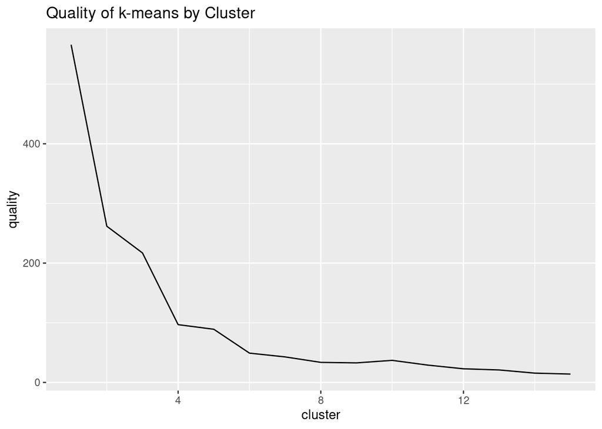

```r
wssplot(newMap$layout,15,100)
```

Plot of the cluster differences for the elbow test. Four and six are the main candidates. Four looks ok I guess, six looks great except it has one cluster with only 8 shots in it, so I also tried 5 to see if that would get rid of it, and it did. As a result, it is the one I’m going with

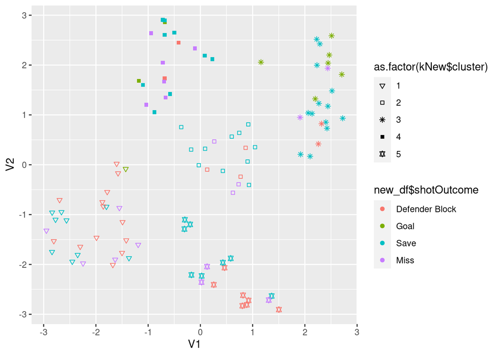

```r
kNew <- kmeans(newMap$layout,5)
ggplot()+
  geom_point(data = as.data.frame(newMap$layout),aes(x = V1,y = V2,shape = as.factor(kNew$cluster),color = new_df$shotOutcome)) +
  scale_shape_manual(values = c(25,22,8,15,11,12))
```

Five clusters makes the most reasonable looking graph. Unfortunately, it still isn’t quite as nice as earlier. Now I’ll run a similar analysis on the clusters as I did previously

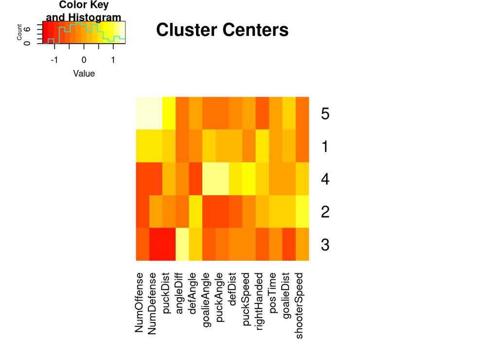

```r
shotsNumNew <- as.data.frame(scale(apply(shotsNumNew,2,as.numeric)))
preimageCentersNew <- shotsNumNew%>% group_by(as.factor(kNew$cluster) ) %>% summarise_all(.funs =  mean)
  #apply(fails,2,median) #do this for each factor
heatDataNew <- as.matrix(preimageCentersNew[,2:(ncol(preimageCentersNew))])
#head(heatDataNew)
heatmap.2(heatDataNew,
          main = "Cluster Centers",
          scale = "none",
          trace = "none",
          dendrogram = "none",
          Colv = TRUE,
          Rowv = TRUE,
          margins = c(8,16))
```

Heatmap will be discussed under “Discussion of Results,” along with the summary table, which one again is the means for each cluster

```r
sumTab$wasSuccess <- ifelse(new_df$outcomes == 2,1,0)
sumTab$wasDB <- ifelse(new_df$shotOutcome == "Defender Block",1,0)
sumTab$wasMiss <- ifelse(new_df$shotOutcome == "Miss",1,0)
summaryTable <- sumTab %>% group_by(as.factor(kNew$cluster)) %>% summarise_all(.funs = mean)
kbl(summaryTable[,1:8],booktabs = T) %>% kable_styling(latex_options = c("striped","scaled_down"),full_width = F,position = "left")
```

| as.factor(kNew$cluster) | puckDist | puckAngle | puckSpeed | shooterSpeed | goalieDist | goalieAngle | posTime |
| --- | --- | --- | --- | --- | --- | --- | --- |
| 1 | 480.2189 | 92.74279 | 37.93688 | 12.24698 | 73.54123 | 89.42210 | 30.03571 |
| 2 | 352.1640 | 58.75496 | 37.85715 | 22.76281 | 77.99395 | 49.67319 | 36.35294 |
| 3 | 204.9807 | 73.83406 | 39.00433 | 15.23265 | 48.45446 | 56.86832 | 23.04348 |
| 4 | 444.3973 | 125.80491 | 54.42665 | 18.94310 | 70.50842 | 124.21303 | 27.10526 |
| 5 | 544.7923 | 72.74759 | 40.63425 | 12.48367 | 78.61590 | 61.27511 | 30.83333 |

```r
kbl(summaryTable[,9:ncol(summaryTable)],booktabs = T) %>% kable_styling(latex_options = c("striped","scaled_down"),full_width = F,position = "left")
```

| NumOffense | NumDefense | rightHanded | defDist | defAngle | angleDiff | wasSuccess | wasDB | wasMiss |
| --- | --- | --- | --- | --- | --- | --- | --- | --- |
| 0.8928571 | 2.535714 | 0.7500000 | 206.8147 | 86.95016 | 12.77057 | 0.0357143 | 0.4642857 | 0.1785714 |
| 0.0000000 | 2.000000 | 0.5294118 | 103.6250 | 133.28207 | 12.28638 | 0.0000000 | 0.1764706 | 0.1764706 |
| 0.1304348 | 1.086957 | 0.1739130 | 165.5673 | 121.62466 | 51.78782 | 0.2608696 | 0.0869565 | 0.0869565 |
| 0.0000000 | 1.473684 | 0.6315789 | 277.6410 | 54.77008 | 15.03603 | 0.1052632 | 0.1052632 | 0.3157895 |
| 1.5000000 | 3.222222 | 0.1666667 | 169.2922 | 101.53911 | 12.63375 | 0.0000000 | 0.3888889 | 0.1666667 |

### Discussion of results

*Provide in natural language a clear discussion of your observations.*

Cluster 1: Pass to the enemy team. About half of these shots were defender blocks, I’m going to add the angle difference between the closest defender and the shot angle for the next analysis, as the mean defender angle and the mean puck angle were way closer here than in any of the other clusters.

Cluster 3: Perfect shot. Everything was aligned. On average, the goalie was off by 50 degrees! The shooter was very close, there were very few defensive players involved, the shooter took the shot quickly, and there also happened to be left handed

Cluster 4: Wide open. The nearest defender was over 277 units away, further than any of the other clusters. They also had a slightly better shot at the goal, as the difference in angle between the goalie and the shooter was 15 degrees, slightly higher than normal. As a result, they were able to achieve a 10% success rate. Most of the time the goalie blocked it, although they had a lot of misses as well. On the bright side, they also hit the puck really hard and got it fast. Not sure if this or being over 30 degrees to the right of the goalie was causing these misses

Cluster 5: “Traffic Jam” - Thanks for the name Ashley. We saw this several weeks earlier, but now that we have DB we can confirm it. They are shooting from very far out with a lot of other players involved (on average, 1.5 offense and over 3 defense). As a result, over a third of the time a defender blocks it.

## Analysis: Question 3: Defender angles

### Question being asked

*Provide in natural language a statement of what question you’re trying to answer*

Is one of the clusters being caused by players shooting directly into the defenders?

### Data Preparation

*Provide in natural language a description of the data you are using for this analysis*

*Include a step-by-step description of how you prepare your data for analysis*

*If you’re re-using dataframes prepared in another section, simply re-state what data you’re using*

I’m using the data and proccessing from question 2, but I’m adding in the difference in angle between the shot and the nearest defender

```r
# Include all data processing code (if necessary), clearly commented
shotsQ3$defAngleDiff <- abs(new_df$defAngle - new_df$puckAngle)
tableQ3 <- shotsQ3
sumTabQ3 <- shotsQ3
shotsQ3 <- one_hot(dt = as.data.table(shotsQ3))
shotsQ3 <- scale(shotsQ3)

sumTabQ3$wasSuccess <- ifelse(new_df$outcomes == 2,1,0)
sumTabQ3$wasDB <- ifelse(new_df$shotOutcome == "Defender Block",1,0)
sumTabQ3$wasMiss <- ifelse(new_df$shotOutcome == "Miss",1,0)
sumTabQ3$NumDefense <- as.numeric(sumTabQ3$NumDefense)
sumTabQ3$NumOffense <- as.numeric(sumTabQ3$NumOffense)
```

### Analysis methods used

*Describe in natural language a statement of the analysis you’re trying to do*

The same analysis from question 2 with the added feature

*Provide clearly commented analysis code; include code for tables and figures!*

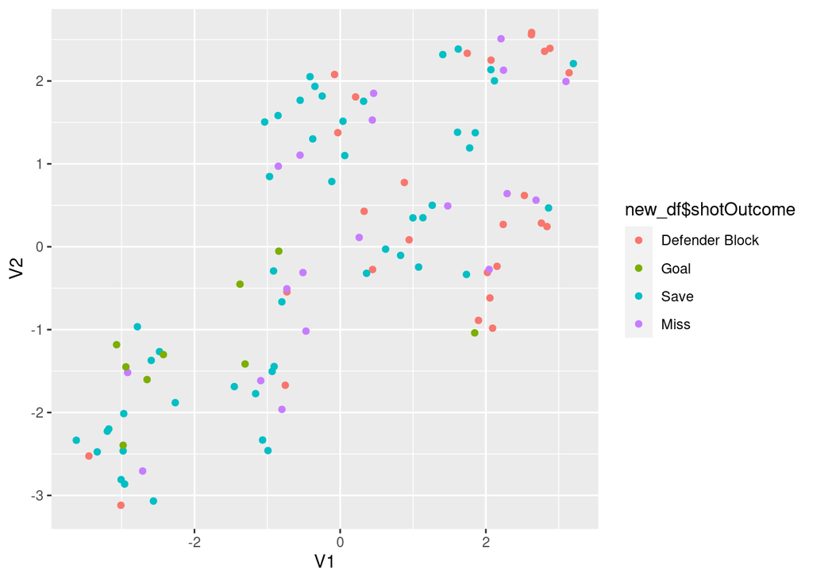

```r
# Include all analysis code, clearly commented
# If not possible, screen shots are acceptable.
# If your contributions included things that are not done in an R-notebook,
#   (e.g. researching, writing, and coding in Python), you still need to do
#   this status notebook in R.  Describe what you did here and put any products
#   that you created in github. If you are writing online documents (e.g. overleaf
#   or google docs), you can include links to the documents in this notebook
#   instead of actual text.
map3 <- umap(shotsQ3,custom.config)

ggplot()+
 geom_point(data = as.data.frame(map3$layout),aes(x = V1,y = V2,color = new_df$shotOutcome))
```

This didn’t really cluster nicely, but I’ll see if K-means agrees with me on that front

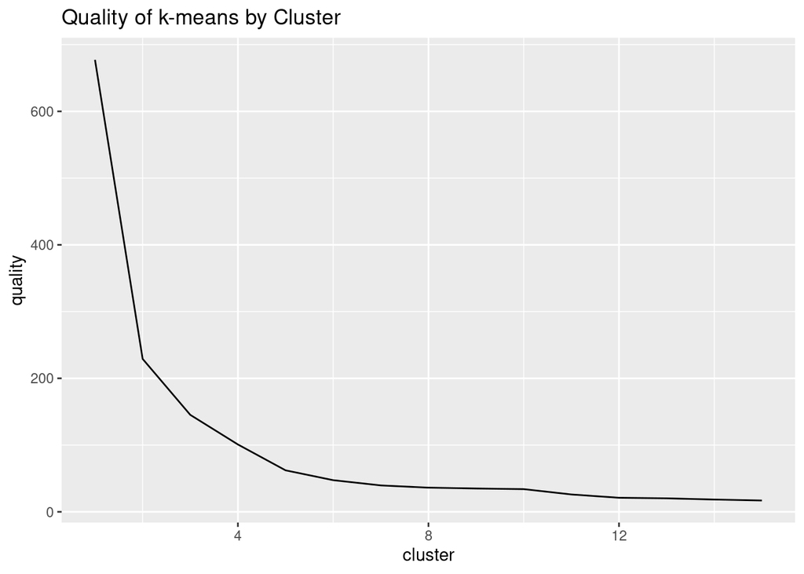

```r
wssplot(map3$layout)
```

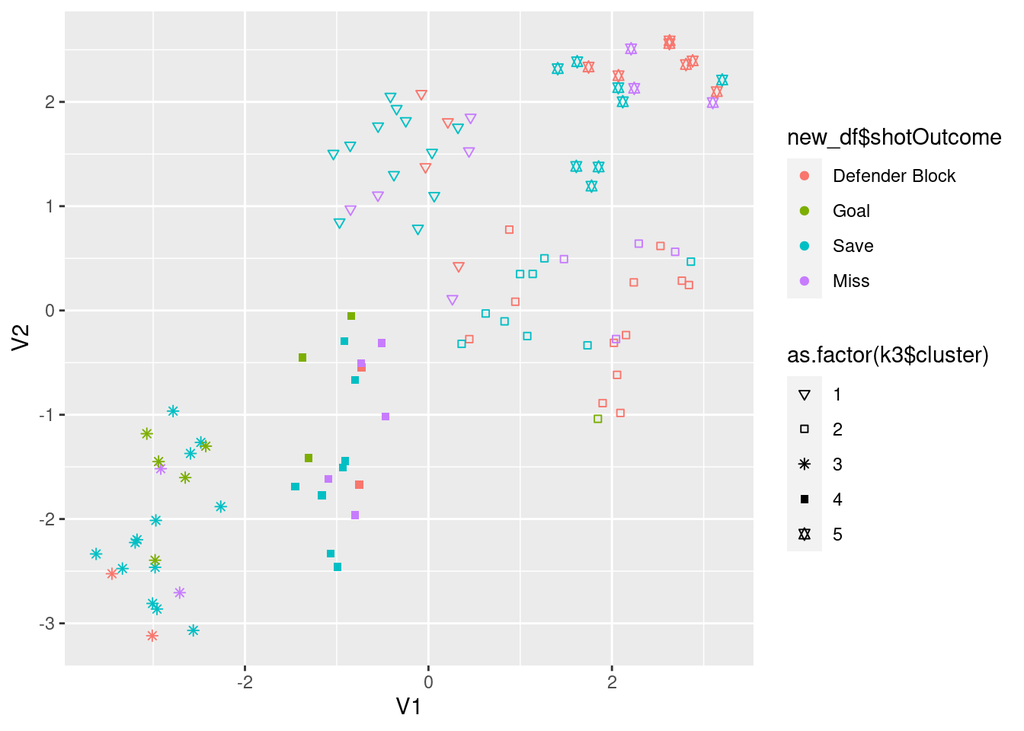

```r
#5 clusters?
k3 <- kmeans(map3$layout,5)
ggplot()+
  geom_point(data = as.data.frame(map3$layout),aes(x = V1,y = V2,shape = as.factor(k3$cluster),color = new_df$shotOutcome)) +
  scale_shape_manual(values = c(25,22,8,15,11,12))
```

That actually doesn’t look that bad, although it does split the goals into two seperate clusters. Heatmap and table of means time!

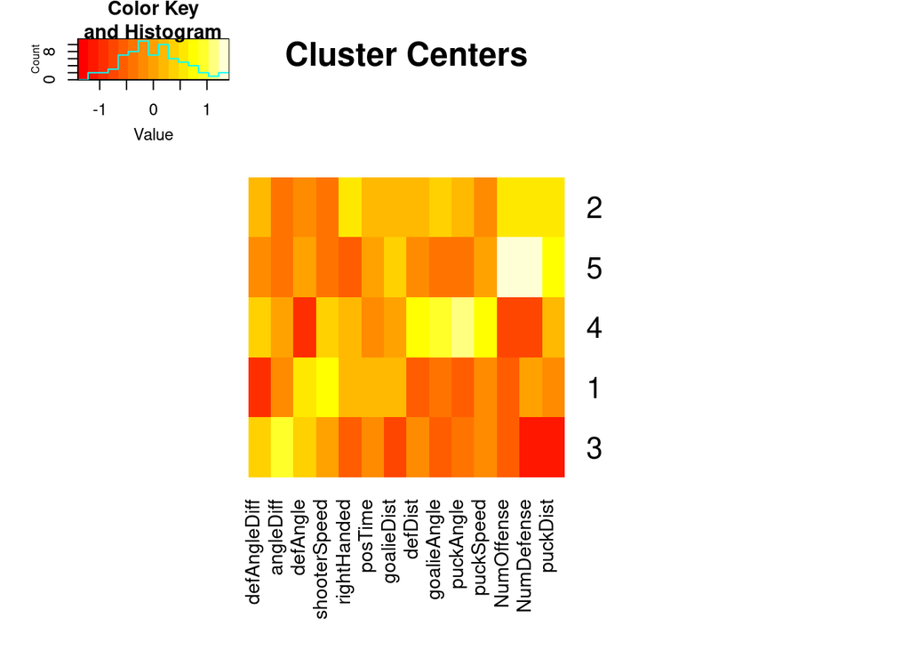

```r
shotsNumNew <- as.data.frame(scale(apply(tableQ3,2,as.numeric)))
preimageCentersNew <- shotsNumNew%>% group_by(as.factor(k3$cluster) ) %>% summarise_all(.funs =  mean)
  #apply(fails,2,median) #do this for each factor
heatDataNew <- as.matrix(preimageCentersNew[,2:(ncol(preimageCentersNew))])
#head(heatDataNew)
heatmap.2(heatDataNew,
          main = "Cluster Centers",
          scale = "none",
          trace = "none",
          dendrogram = "none",
          Colv = TRUE,
          Rowv = TRUE,
          margins = c(8,16))
```

```r
sumTab$wasSuccess <- ifelse(new_df$outcomes == 2,1,0)
sumTab$wasDB <- ifelse(new_df$shotOutcome == "Defender Block",1,0)
sumTab$wasMiss <- ifelse(new_df$shotOutcome == "Miss",1,0)
summaryTable <- sumTabQ3 %>% group_by(as.factor(kNew$cluster)) %>% summarise_all(.funs = mean)
kbl(summaryTable[,1:8],booktabs = T) %>% kable_styling(latex_options = c("striped","scaled_down"),full_width = F,position = "left")
```

| as.factor(kNew$cluster) | puckDist | puckAngle | puckSpeed | shooterSpeed | goalieDist | goalieAngle | posTime |
| --- | --- | --- | --- | --- | --- | --- | --- |
| 1 | 480.2189 | 92.74279 | 37.93688 | 12.24698 | 73.54123 | 89.42210 | 30.03571 |
| 2 | 352.1640 | 58.75496 | 37.85715 | 22.76281 | 77.99395 | 49.67319 | 36.35294 |
| 3 | 204.9807 | 73.83406 | 39.00433 | 15.23265 | 48.45446 | 56.86832 | 23.04348 |
| 4 | 444.3973 | 125.80491 | 54.42665 | 18.94310 | 70.50842 | 124.21303 | 27.10526 |
| 5 | 544.7923 | 72.74759 | 40.63425 | 12.48367 | 78.61590 | 61.27511 | 30.83333 |

```r
kbl(summaryTable[,9:17],booktabs = T) %>% kable_styling(latex_options = c("striped","scaled_down"),full_width = F,position = "left")
```

| NumOffense | NumDefense | rightHanded | defDist | defAngle | angleDiff | defAngleDiff | wasSuccess | wasDB |
| --- | --- | --- | --- | --- | --- | --- | --- | --- |
| 1.892857 | 2.535714 | 0.7500000 | 206.8147 | 86.95016 | 12.77057 | 84.15031 | 0.0357143 | 0.4642857 |
| 1.000000 | 2.000000 | 0.5294118 | 103.6250 | 133.28207 | 12.28638 | 74.52711 | 0.0000000 | 0.1764706 |
| 1.130435 | 1.086957 | 0.1739130 | 165.5673 | 121.62466 | 51.78782 | 86.49131 | 0.2608696 | 0.0869565 |
| 1.000000 | 1.473684 | 0.6315789 | 277.6410 | 54.77008 | 15.03603 | 80.49837 | 0.1052632 | 0.1052632 |
| 2.500000 | 3.222222 | 0.1666667 | 169.2922 | 101.53911 | 12.63375 | 79.58732 | 0.0000000 | 0.3888889 |

```r
kbl(summaryTable[,18:ncol(summaryTable)],booktabs = T) %>% kable_styling(latex_options = c("striped","scaled_down"),full_width = F,position = "left")
```

| wasMiss |
| --- |
| 0.1785714 |
| 0.1764706 |
| 0.0869565 |
| 0.3157895 |
| 0.1666667 |

### Discussion of results

*Provide in natural language a clear discussion of your observations.*

## Summary and next steps

*Provide in natural language a clear summary and your proposed next steps.*

Overall, there appears to be 5 separate clusters as outlined in Question 2, with one major goal cluster and another that has a few clusters. For next steps, I could work on making this analysis more presentable to a wider audience by improving graphs and also potentially working with some new data, as apparently there is an updated data frame that will be pushed tonight.